# Risk Factor Analysis

## Outcome Variable

**Outcome Variable:** swasted

## Predictor Variables

**Intervention Variable:** feducyrs

**Adjustment Set:**

- arm
- W_mage
- meducyrs
- hhwealth_quart
- W_mhtcm
- W_mwtkg
- W_mbmi
- W_gagebrth
- W_birthwt
- W_birthlen
- single
- delta_W_mage
- delta_meducyrs
- delta_hhwealth_quart
- delta_W_mhtcm
- delta_W_mwtkg
- delta_W_mbmi
- delta_W_gagebrth
- delta_W_birthwt
- delta_W_birthlen
- delta_single

## Stratifying Variables

The analysis was stratified on these variable(s):

- agecat
- studyid
- country

## Data Summary

| agecat | studyid | country | feducyrs | swasted | n_cell | n |
| --- | --- | --- | --- | --- | --- | --- |
| Birth | ki0047075b-MAL-ED | BANGLADESH | High | 0 | 42 | 119 |
| Birth | ki0047075b-MAL-ED | BANGLADESH | High | 1 | 2 | 119 |
| Birth | ki0047075b-MAL-ED | BANGLADESH | Low | 0 | 30 | 119 |
| Birth | ki0047075b-MAL-ED | BANGLADESH | Low | 1 | 3 | 119 |
| Birth | ki0047075b-MAL-ED | BANGLADESH | Medium | 0 | 41 | 119 |
| Birth | ki0047075b-MAL-ED | BANGLADESH | Medium | 1 | 1 | 119 |
| Birth | ki0047075b-MAL-ED | INDIA | High | 0 | 7 | 23 |
| Birth | ki0047075b-MAL-ED | INDIA | High | 1 | 0 | 23 |
| Birth | ki0047075b-MAL-ED | INDIA | Low | 0 | 13 | 23 |
| Birth | ki0047075b-MAL-ED | INDIA | Low | 1 | 0 | 23 |
| Birth | ki0047075b-MAL-ED | INDIA | Medium | 0 | 3 | 23 |
| Birth | ki0047075b-MAL-ED | INDIA | Medium | 1 | 0 | 23 |
| Birth | ki0047075b-MAL-ED | NEPAL | High | 0 | 3 | 9 |
| Birth | ki0047075b-MAL-ED | NEPAL | High | 1 | 0 | 9 |
| Birth | ki0047075b-MAL-ED | NEPAL | Low | 0 | 3 | 9 |
| Birth | ki0047075b-MAL-ED | NEPAL | Low | 1 | 0 | 9 |
| Birth | ki0047075b-MAL-ED | NEPAL | Medium | 0 | 3 | 9 |
| Birth | ki0047075b-MAL-ED | NEPAL | Medium | 1 | 0 | 9 |
| Birth | ki0047075b-MAL-ED | PERU | High | 0 | 84 | 190 |
| Birth | ki0047075b-MAL-ED | PERU | High | 1 | 0 | 190 |
| Birth | ki0047075b-MAL-ED | PERU | Low | 0 | 56 | 190 |
| Birth | ki0047075b-MAL-ED | PERU | Low | 1 | 0 | 190 |
| Birth | ki0047075b-MAL-ED | PERU | Medium | 0 | 50 | 190 |
| Birth | ki0047075b-MAL-ED | PERU | Medium | 1 | 0 | 190 |
| Birth | ki0047075b-MAL-ED | SOUTH AFRICA | High | 0 | 10 | 33 |
| Birth | ki0047075b-MAL-ED | SOUTH AFRICA | High | 1 | 0 | 33 |
| Birth | ki0047075b-MAL-ED | SOUTH AFRICA | Low | 0 | 14 | 33 |
| Birth | ki0047075b-MAL-ED | SOUTH AFRICA | Low | 1 | 0 | 33 |
| Birth | ki0047075b-MAL-ED | SOUTH AFRICA | Medium | 0 | 9 | 33 |
| Birth | ki0047075b-MAL-ED | SOUTH AFRICA | Medium | 1 | 0 | 33 |

[output cut: 300 more lines]

The following strata were considered:

- agecat: 24 months, studyid: ki0047075b-MAL-ED, country: BANGLADESH
- agecat: 24 months, studyid: ki0047075b-MAL-ED, country: INDIA
- agecat: 24 months, studyid: ki0047075b-MAL-ED, country: NEPAL
- agecat: 24 months, studyid: ki0047075b-MAL-ED, country: PERU
- agecat: 24 months, studyid: ki0047075b-MAL-ED, country: SOUTH AFRICA
- agecat: 24 months, studyid: ki0047075b-MAL-ED, country: TANZANIA, UNITED REPUBLIC OF
- agecat: 24 months, studyid: ki1017093b-PROVIDE, country: BANGLADESH
- agecat: 24 months, studyid: ki1017093c-NIH-Crypto, country: BANGLADESH
- agecat: 24 months, studyid: ki1066203-TanzaniaChild2, country: TANZANIA, UNITED REPUBLIC OF
- agecat: 24 months, studyid: ki1113344-GMS-Nepal, country: NEPAL
- agecat: 24 months, studyid: ki1119695-PROBIT, country: BELARUS
- agecat: 24 months, studyid: ki1126311-ZVITAMBO, country: ZIMBABWE
- agecat: 24 months, studyid: ki1135781-COHORTS, country: GUATEMALA
- agecat: 24 months, studyid: ki1135781-COHORTS, country: INDIA
- agecat: 24 months, studyid: ki1135781-COHORTS, country: PHILIPPINES
- agecat: 24 months, studyid: ki1148112-LCNI-5, country: MALAWI
- agecat: 24 months, studyid: kiGH5241-JiVitA-3, country: BANGLADESH
- agecat: 24 months, studyid: kiGH5241-JiVitA-4, country: BANGLADESH
- agecat: 6 months, studyid: ki0047075b-MAL-ED, country: BANGLADESH
- agecat: 6 months, studyid: ki0047075b-MAL-ED, country: INDIA
- agecat: 6 months, studyid: ki0047075b-MAL-ED, country: NEPAL
- agecat: 6 months, studyid: ki0047075b-MAL-ED, country: PERU
- agecat: 6 months, studyid: ki0047075b-MAL-ED, country: SOUTH AFRICA
- agecat: 6 months, studyid: ki0047075b-MAL-ED, country: TANZANIA, UNITED REPUBLIC OF
- agecat: 6 months, studyid: ki1000304b-SAS-CompFeed, country: INDIA
- agecat: 6 months, studyid: ki1000304b-SAS-FoodSuppl, country: INDIA
- agecat: 6 months, studyid: ki1017093b-PROVIDE, country: BANGLADESH
- agecat: 6 months, studyid: ki1017093c-NIH-Crypto, country: BANGLADESH
- agecat: 6 months, studyid: ki1066203-TanzaniaChild2, country: TANZANIA, UNITED REPUBLIC OF
- agecat: 6 months, studyid: ki1113344-GMS-Nepal, country: NEPAL
- agecat: 6 months, studyid: ki1119695-PROBIT, country: BELARUS
- agecat: 6 months, studyid: ki1126311-ZVITAMBO, country: ZIMBABWE
- agecat: 6 months, studyid: ki1135781-COHORTS, country: GUATEMALA
- agecat: 6 months, studyid: ki1135781-COHORTS, country: INDIA
- agecat: 6 months, studyid: ki1135781-COHORTS, country: PHILIPPINES
- agecat: 6 months, studyid: ki1148112-LCNI-5, country: MALAWI
- agecat: 6 months, studyid: kiGH5241-JiVitA-3, country: BANGLADESH
- agecat: 6 months, studyid: kiGH5241-JiVitA-4, country: BANGLADESH
- agecat: Birth, studyid: ki0047075b-MAL-ED, country: BANGLADESH
- agecat: Birth, studyid: ki0047075b-MAL-ED, country: INDIA
- agecat: Birth, studyid: ki0047075b-MAL-ED, country: NEPAL
- agecat: Birth, studyid: ki0047075b-MAL-ED, country: PERU
- agecat: Birth, studyid: ki0047075b-MAL-ED, country: SOUTH AFRICA
- agecat: Birth, studyid: ki0047075b-MAL-ED, country: TANZANIA, UNITED REPUBLIC OF
- agecat: Birth, studyid: ki1000304b-SAS-CompFeed, country: INDIA
- agecat: Birth, studyid: ki1017093b-PROVIDE, country: BANGLADESH
- agecat: Birth, studyid: ki1017093c-NIH-Crypto, country: BANGLADESH
- agecat: Birth, studyid: ki1113344-GMS-Nepal, country: NEPAL
- agecat: Birth, studyid: ki1119695-PROBIT, country: BELARUS
- agecat: Birth, studyid: ki1126311-ZVITAMBO, country: ZIMBABWE
- agecat: Birth, studyid: ki1135781-COHORTS, country: GUATEMALA
- agecat: Birth, studyid: ki1135781-COHORTS, country: INDIA
- agecat: Birth, studyid: ki1135781-COHORTS, country: PHILIPPINES
- agecat: Birth, studyid: kiGH5241-JiVitA-3, country: BANGLADESH
- agecat: Birth, studyid: kiGH5241-JiVitA-4, country: BANGLADESH

### Dropped Strata

Some strata were dropped due to rare outcomes:

- agecat: Birth, studyid: ki0047075b-MAL-ED, country: BANGLADESH
- agecat: Birth, studyid: ki0047075b-MAL-ED, country: INDIA
- agecat: Birth, studyid: ki0047075b-MAL-ED, country: NEPAL
- agecat: Birth, studyid: ki0047075b-MAL-ED, country: PERU
- agecat: Birth, studyid: ki0047075b-MAL-ED, country: SOUTH AFRICA
- agecat: Birth, studyid: ki0047075b-MAL-ED, country: TANZANIA, UNITED REPUBLIC OF
- agecat: Birth, studyid: ki1017093b-PROVIDE, country: BANGLADESH
- agecat: 6 months, studyid: ki0047075b-MAL-ED, country: BANGLADESH
- agecat: 6 months, studyid: ki0047075b-MAL-ED, country: INDIA
- agecat: 6 months, studyid: ki0047075b-MAL-ED, country: NEPAL
- agecat: 6 months, studyid: ki0047075b-MAL-ED, country: PERU
- agecat: 6 months, studyid: ki0047075b-MAL-ED, country: SOUTH AFRICA
- agecat: 6 months, studyid: ki0047075b-MAL-ED, country: TANZANIA, UNITED REPUBLIC OF
- agecat: 6 months, studyid: ki1017093b-PROVIDE, country: BANGLADESH
- agecat: 6 months, studyid: ki1017093c-NIH-Crypto, country: BANGLADESH
- agecat: 6 months, studyid: ki1066203-TanzaniaChild2, country: TANZANIA, UNITED REPUBLIC OF
- agecat: 6 months, studyid: ki1113344-GMS-Nepal, country: NEPAL
- agecat: 6 months, studyid: ki1119695-PROBIT, country: BELARUS
- agecat: 6 months, studyid: ki1135781-COHORTS, country: GUATEMALA
- agecat: 6 months, studyid: ki1148112-LCNI-5, country: MALAWI
- agecat: 6 months, studyid: kiGH5241-JiVitA-4, country: BANGLADESH
- agecat: 24 months, studyid: ki0047075b-MAL-ED, country: BANGLADESH
- agecat: 24 months, studyid: ki0047075b-MAL-ED, country: INDIA
- agecat: 24 months, studyid: ki0047075b-MAL-ED, country: NEPAL
- agecat: 24 months, studyid: ki0047075b-MAL-ED, country: PERU
- agecat: 24 months, studyid: ki0047075b-MAL-ED, country: SOUTH AFRICA
- agecat: 24 months, studyid: ki0047075b-MAL-ED, country: TANZANIA, UNITED REPUBLIC OF
- agecat: 24 months, studyid: ki1017093b-PROVIDE, country: BANGLADESH
- agecat: 24 months, studyid: ki1017093c-NIH-Crypto, country: BANGLADESH
- agecat: 24 months, studyid: ki1066203-TanzaniaChild2, country: TANZANIA, UNITED REPUBLIC OF
- agecat: 24 months, studyid: ki1113344-GMS-Nepal, country: NEPAL
- agecat: 24 months, studyid: ki1119695-PROBIT, country: BELARUS
- agecat: 24 months, studyid: ki1126311-ZVITAMBO, country: ZIMBABWE
- agecat: 24 months, studyid: ki1135781-COHORTS, country: GUATEMALA
- agecat: 24 months, studyid: ki1135781-COHORTS, country: INDIA
- agecat: 24 months, studyid: ki1135781-COHORTS, country: PHILIPPINES
- agecat: 24 months, studyid: ki1148112-LCNI-5, country: MALAWI

## Methods Detail

We’re interested in the causal parameters $E[Y_a]$ for all values of $a \in \mathcal{A}$. These parameters represent the mean outcome if, possibly contrary to fact, we intervened to set all units to have $A=a$. Under the randomization and positivity assumptions, these are identified by the statistical parameters $\psi_a=E_W[E_{Y|A,W}(Y|A=a,W)]$. In addition, we’re interested in the mean of $Y$, $E[Y]$ under no intervention (the observed mean). We will estimate these parameters by using SuperLearner to fit the relevant likelihood factors – $E_{Y|A,W}(Y|A=a,W)$ and $p(A=a|W)$, and then updating our likelihood fit using a joint TMLE.

For unadjusted analyses ($W=\{\}$), initial likelihoods were estimated using Lrnr_glm to estimate the simple $E(Y|A)$ and Lrnr_mean to estimate $p(A)$. For adjusted analyses, a small library containing Lrnr_glmnet, Lrnr_xgboost, and Lrnr_mean was used.

Having estimated these parameters, we will then use the delta method to estimate relative risks and attributable risks relative to a prespecified baseline level of $A$.

# Results Detail

## Results Plots

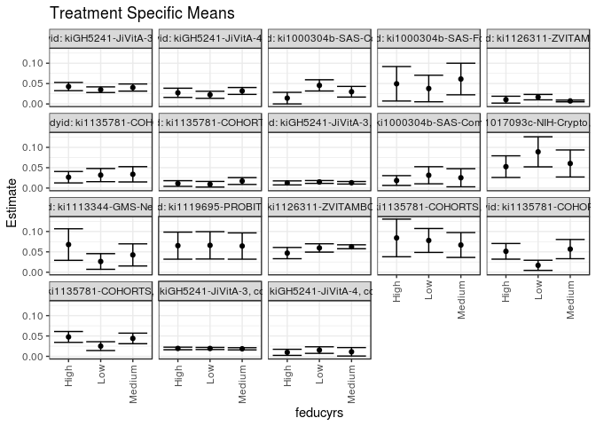

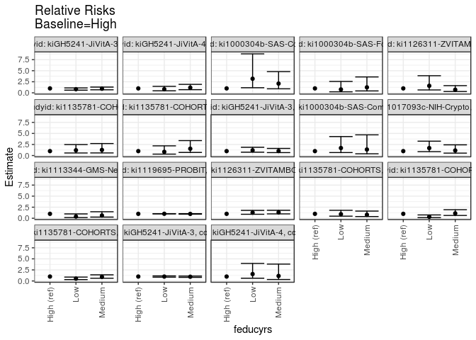

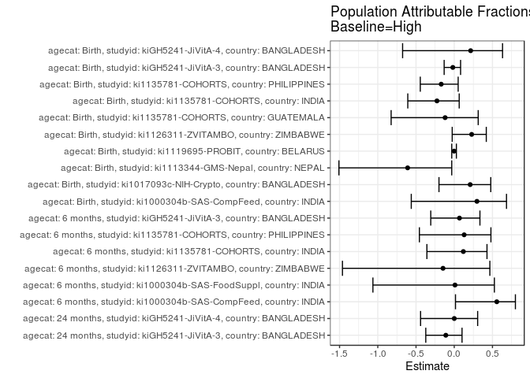

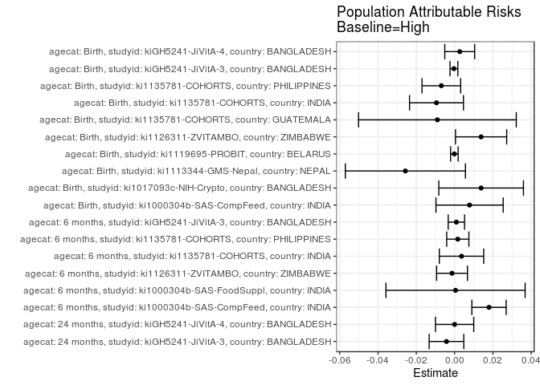

## Results Table

### Parameter: TSM

| agecat | studyid | country | intervention_level | baseline_level | estimate | ci_lower | ci_upper |
| --- | --- | --- | --- | --- | --- | --- | --- |
| Birth | ki1000304b-SAS-CompFeed | INDIA | High | NA | 0.0185185 | 0.0065073 | 0.0305297 |
| Birth | ki1000304b-SAS-CompFeed | INDIA | Low | NA | 0.0315126 | 0.0105174 | 0.0525078 |
| Birth | ki1000304b-SAS-CompFeed | INDIA | Medium | NA | 0.0253521 | 0.0030904 | 0.0476138 |
| Birth | ki1017093c-NIH-Crypto | BANGLADESH | High | NA | 0.0526236 | 0.0260471 | 0.0792001 |
| Birth | ki1017093c-NIH-Crypto | BANGLADESH | Low | NA | 0.0890370 | 0.0521267 | 0.1259473 |
| Birth | ki1017093c-NIH-Crypto | BANGLADESH | Medium | NA | 0.0604068 | 0.0272513 | 0.0935623 |
| Birth | ki1113344-GMS-Nepal | NEPAL | High | NA | 0.0679012 | 0.0291309 | 0.1066716 |
| Birth | ki1113344-GMS-Nepal | NEPAL | Low | NA | 0.0263158 | 0.0070643 | 0.0455673 |
| Birth | ki1113344-GMS-Nepal | NEPAL | Medium | NA | 0.0424528 | 0.0152914 | 0.0696143 |
| Birth | ki1119695-PROBIT | BELARUS | High | NA | 0.0652218 | 0.0319779 | 0.0984656 |
| Birth | ki1119695-PROBIT | BELARUS | Low | NA | 0.0659888 | 0.0324478 | 0.0995297 |
| Birth | ki1119695-PROBIT | BELARUS | Medium | NA | 0.0642972 | 0.0320320 | 0.0965624 |
| Birth | ki1126311-ZVITAMBO | ZIMBABWE | High | NA | 0.0469214 | 0.0331278 | 0.0607151 |
| Birth | ki1126311-ZVITAMBO | ZIMBABWE | Low | NA | 0.0595535 | 0.0493643 | 0.0697427 |
| Birth | ki1126311-ZVITAMBO | ZIMBABWE | Medium | NA | 0.0624343 | 0.0576137 | 0.0672549 |
| Birth | ki1135781-COHORTS | GUATEMALA | High | NA | 0.0841917 | 0.0379789 | 0.1304045 |
| Birth | ki1135781-COHORTS | GUATEMALA | Low | NA | 0.0779231 | 0.0485055 | 0.1073407 |
| Birth | ki1135781-COHORTS | GUATEMALA | Medium | NA | 0.0668144 | 0.0362681 | 0.0973608 |
| Birth | ki1135781-COHORTS | INDIA | High | NA | 0.0512821 | 0.0320749 | 0.0704892 |
| Birth | ki1135781-COHORTS | INDIA | Low | NA | 0.0169082 | 0.0044842 | 0.0293322 |
| Birth | ki1135781-COHORTS | INDIA | Medium | NA | 0.0567568 | 0.0331717 | 0.0803418 |
| Birth | ki1135781-COHORTS | PHILIPPINES | High | NA | 0.0476263 | 0.0343017 | 0.0609508 |
| Birth | ki1135781-COHORTS | PHILIPPINES | Low | NA | 0.0250722 | 0.0142184 | 0.0359260 |
| Birth | ki1135781-COHORTS | PHILIPPINES | Medium | NA | 0.0440060 | 0.0310209 | 0.0569910 |
| Birth | kiGH5241-JiVitA-3 | BANGLADESH | High | NA | 0.0193586 | 0.0162121 | 0.0225052 |
| Birth | kiGH5241-JiVitA-3 | BANGLADESH | Low | NA | 0.0192926 | 0.0166808 | 0.0219044 |
| Birth | kiGH5241-JiVitA-3 | BANGLADESH | Medium | NA | 0.0185144 | 0.0158353 | 0.0211935 |
| Birth | kiGH5241-JiVitA-4 | BANGLADESH | High | NA | 0.0098039 | 0.0022932 | 0.0173147 |
| Birth | kiGH5241-JiVitA-4 | BANGLADESH | Low | NA | 0.0153341 | 0.0072544 | 0.0234137 |
| Birth | kiGH5241-JiVitA-4 | BANGLADESH | Medium | NA | 0.0111111 | 0.0007252 | 0.0214971 |
| 6 months | ki1000304b-SAS-CompFeed | INDIA | High | NA | 0.0143266 | 0.0000589 | 0.0285944 |
| 6 months | ki1000304b-SAS-CompFeed | INDIA | Low | NA | 0.0456204 | 0.0318281 | 0.0594127 |
| 6 months | ki1000304b-SAS-CompFeed | INDIA | Medium | NA | 0.0299539 | 0.0168697 | 0.0430382 |
| 6 months | ki1000304b-SAS-FoodSuppl | INDIA | High | NA | 0.0495050 | 0.0071447 | 0.0918652 |
| 6 months | ki1000304b-SAS-FoodSuppl | INDIA | Low | NA | 0.0378788 | 0.0052691 | 0.0704884 |
| 6 months | ki1000304b-SAS-FoodSuppl | INDIA | Medium | NA | 0.0612245 | 0.0224179 | 0.1000310 |
| 6 months | ki1126311-ZVITAMBO | ZIMBABWE | High | NA | 0.0105448 | 0.0021515 | 0.0189382 |
| 6 months | ki1126311-ZVITAMBO | ZIMBABWE | Low | NA | 0.0167481 | 0.0101035 | 0.0233926 |
| 6 months | ki1126311-ZVITAMBO | ZIMBABWE | Medium | NA | 0.0073436 | 0.0052291 | 0.0094580 |
| 6 months | ki1135781-COHORTS | INDIA | High | NA | 0.0267152 | 0.0126890 | 0.0407414 |
| 6 months | ki1135781-COHORTS | INDIA | Low | NA | 0.0319089 | 0.0157533 | 0.0480645 |
| 6 months | ki1135781-COHORTS | INDIA | Medium | NA | 0.0338226 | 0.0150769 | 0.0525683 |
| 6 months | ki1135781-COHORTS | PHILIPPINES | High | NA | 0.0112108 | 0.0043001 | 0.0181214 |
| 6 months | ki1135781-COHORTS | PHILIPPINES | Low | NA | 0.0094086 | 0.0024703 | 0.0163470 |
| 6 months | ki1135781-COHORTS | PHILIPPINES | Medium | NA | 0.0172786 | 0.0088841 | 0.0256732 |
| 6 months | kiGH5241-JiVitA-3 | BANGLADESH | High | NA | 0.0126686 | 0.0077328 | 0.0176045 |
| 6 months | kiGH5241-JiVitA-3 | BANGLADESH | Low | NA | 0.0150453 | 0.0115545 | 0.0185361 |
| 6 months | kiGH5241-JiVitA-3 | BANGLADESH | Medium | NA | 0.0130856 | 0.0099675 | 0.0162036 |
| 24 months | kiGH5241-JiVitA-3 | BANGLADESH | High | NA | 0.0427218 | 0.0325870 | 0.0528566 |
| 24 months | kiGH5241-JiVitA-3 | BANGLADESH | Low | NA | 0.0350076 | 0.0281326 | 0.0418826 |
| 24 months | kiGH5241-JiVitA-3 | BANGLADESH | Medium | NA | 0.0402788 | 0.0315353 | 0.0490222 |
| 24 months | kiGH5241-JiVitA-4 | BANGLADESH | High | NA | 0.0273699 | 0.0160849 | 0.0386549 |
| 24 months | kiGH5241-JiVitA-4 | BANGLADESH | Low | NA | 0.0225381 | 0.0138992 | 0.0311770 |
| 24 months | kiGH5241-JiVitA-4 | BANGLADESH | Medium | NA | 0.0319171 | 0.0234706 | 0.0403637 |

### Parameter: E(Y)

| agecat | studyid | country | intervention_level | baseline_level | estimate | ci_lower | ci_upper |
| --- | --- | --- | --- | --- | --- | --- | --- |
| Birth | ki1000304b-SAS-CompFeed | INDIA | NA | NA | 0.0263397 | 0.0123159 | 0.0403635 |
| Birth | ki1017093c-NIH-Crypto | BANGLADESH | NA | NA | 0.0664781 | 0.0481022 | 0.0848539 |
| Birth | ki1113344-GMS-Nepal | NEPAL | NA | NA | 0.0421875 | 0.0266017 | 0.0577733 |
| Birth | ki1119695-PROBIT | BELARUS | NA | NA | 0.0651003 | 0.0321310 | 0.0980696 |
| Birth | ki1126311-ZVITAMBO | ZIMBABWE | NA | NA | 0.0607651 | 0.0565891 | 0.0649411 |
| Birth | ki1135781-COHORTS | GUATEMALA | NA | NA | 0.0752089 | 0.0559050 | 0.0945128 |
| Birth | ki1135781-COHORTS | INDIA | NA | NA | 0.0418280 | 0.0309034 | 0.0527527 |
| Birth | ki1135781-COHORTS | PHILIPPINES | NA | NA | 0.0406891 | 0.0332739 | 0.0481044 |
| Birth | kiGH5241-JiVitA-3 | BANGLADESH | NA | NA | 0.0190016 | 0.0166360 | 0.0213671 |
| Birth | kiGH5241-JiVitA-4 | BANGLADESH | NA | NA | 0.0124839 | 0.0071213 | 0.0178464 |
| 6 months | ki1000304b-SAS-CompFeed | INDIA | NA | NA | 0.0323065 | 0.0236135 | 0.0409996 |
| 6 months | ki1000304b-SAS-FoodSuppl | INDIA | NA | NA | 0.0500000 | 0.0280580 | 0.0719420 |
| 6 months | ki1126311-ZVITAMBO | ZIMBABWE | NA | NA | 0.0091943 | 0.0071366 | 0.0112520 |
| 6 months | ki1135781-COHORTS | INDIA | NA | NA | 0.0303249 | 0.0212906 | 0.0393592 |
| 6 months | ki1135781-COHORTS | PHILIPPINES | NA | NA | 0.0128806 | 0.0085134 | 0.0172477 |
| 6 months | kiGH5241-JiVitA-3 | BANGLADESH | NA | NA | 0.0135983 | 0.0114298 | 0.0157667 |
| 24 months | kiGH5241-JiVitA-3 | BANGLADESH | NA | NA | 0.0384802 | 0.0340611 | 0.0428992 |
| 24 months | kiGH5241-JiVitA-4 | BANGLADESH | NA | NA | 0.0273794 | 0.0221191 | 0.0326397 |

### Parameter: RR

| agecat | studyid | country | intervention_level | baseline_level | estimate | ci_lower | ci_upper |
| --- | --- | --- | --- | --- | --- | --- | --- |
| Birth | ki1000304b-SAS-CompFeed | INDIA | High | High | 1.0000000 | 1.0000000 | 1.0000000 |
| Birth | ki1000304b-SAS-CompFeed | INDIA | Low | High | 1.7016806 | 0.6748438 | 4.2909440 |
| Birth | ki1000304b-SAS-CompFeed | INDIA | Medium | High | 1.3690141 | 0.4004177 | 4.6806115 |
| Birth | ki1017093c-NIH-Crypto | BANGLADESH | High | High | 1.0000000 | 1.0000000 | 1.0000000 |
| Birth | ki1017093c-NIH-Crypto | BANGLADESH | Low | High | 1.6919602 | 0.8805038 | 3.2512403 |
| Birth | ki1017093c-NIH-Crypto | BANGLADESH | Medium | High | 1.1479034 | 0.5446434 | 2.4193483 |
| Birth | ki1113344-GMS-Nepal | NEPAL | High | High | 1.0000000 | 1.0000000 | 1.0000000 |
| Birth | ki1113344-GMS-Nepal | NEPAL | Low | High | 0.3875598 | 0.1532184 | 0.9803170 |
| Birth | ki1113344-GMS-Nepal | NEPAL | Medium | High | 0.6252144 | 0.2652196 | 1.4738465 |
| Birth | ki1119695-PROBIT | BELARUS | High | High | 1.0000000 | 1.0000000 | 1.0000000 |
| Birth | ki1119695-PROBIT | BELARUS | Low | High | 1.0117599 | 0.9827327 | 1.0416445 |
| Birth | ki1119695-PROBIT | BELARUS | Medium | High | 0.9858247 | 0.9361443 | 1.0381417 |
| Birth | ki1126311-ZVITAMBO | ZIMBABWE | High | High | 1.0000000 | 1.0000000 | 1.0000000 |
| Birth | ki1126311-ZVITAMBO | ZIMBABWE | Low | High | 1.2692188 | 0.9038280 | 1.7823263 |
| Birth | ki1126311-ZVITAMBO | ZIMBABWE | Medium | High | 1.3306143 | 0.9825785 | 1.8019267 |
| Birth | ki1135781-COHORTS | GUATEMALA | High | High | 1.0000000 | 1.0000000 | 1.0000000 |
| Birth | ki1135781-COHORTS | GUATEMALA | Low | High | 0.9255437 | 0.4765207 | 1.7976787 |
| Birth | ki1135781-COHORTS | GUATEMALA | Medium | High | 0.7935987 | 0.3888587 | 1.6196087 |
| Birth | ki1135781-COHORTS | INDIA | High | High | 1.0000000 | 1.0000000 | 1.0000000 |
| Birth | ki1135781-COHORTS | INDIA | Low | High | 0.3297102 | 0.1445278 | 0.7521652 |
| Birth | ki1135781-COHORTS | INDIA | Medium | High | 1.1067568 | 0.6325520 | 1.9364582 |
| Birth | ki1135781-COHORTS | PHILIPPINES | High | High | 1.0000000 | 1.0000000 | 1.0000000 |
| Birth | ki1135781-COHORTS | PHILIPPINES | Low | High | 0.5264363 | 0.3145760 | 0.8809802 |
| Birth | ki1135781-COHORTS | PHILIPPINES | Medium | High | 0.9239850 | 0.6156572 | 1.3867266 |
| Birth | kiGH5241-JiVitA-3 | BANGLADESH | High | High | 1.0000000 | 1.0000000 | 1.0000000 |
| Birth | kiGH5241-JiVitA-3 | BANGLADESH | Low | High | 0.9965886 | 0.8648724 | 1.1483645 |
| Birth | kiGH5241-JiVitA-3 | BANGLADESH | Medium | High | 0.9563886 | 0.8219617 | 1.1128001 |
| Birth | kiGH5241-JiVitA-4 | BANGLADESH | High | High | 1.0000000 | 1.0000000 | 1.0000000 |
| Birth | kiGH5241-JiVitA-4 | BANGLADESH | Low | High | 1.5640745 | 0.6170812 | 3.9643549 |
| Birth | kiGH5241-JiVitA-4 | BANGLADESH | Medium | High | 1.1333333 | 0.3365230 | 3.8168098 |
| 6 months | ki1000304b-SAS-CompFeed | INDIA | High | High | 1.0000000 | 1.0000000 | 1.0000000 |
| 6 months | ki1000304b-SAS-CompFeed | INDIA | Low | High | 3.1843066 | 1.1506464 | 8.8122711 |
| 6 months | ki1000304b-SAS-CompFeed | INDIA | Medium | High | 2.0907834 | 0.9108342 | 4.7993096 |
| 6 months | ki1000304b-SAS-FoodSuppl | INDIA | High | High | 1.0000000 | 1.0000000 | 1.0000000 |
| 6 months | ki1000304b-SAS-FoodSuppl | INDIA | Low | High | 0.7651515 | 0.2272994 | 2.5757078 |
| 6 months | ki1000304b-SAS-FoodSuppl | INDIA | Medium | High | 1.2367347 | 0.4263944 | 3.5870847 |
| 6 months | ki1126311-ZVITAMBO | ZIMBABWE | High | High | 1.0000000 | 1.0000000 | 1.0000000 |
| 6 months | ki1126311-ZVITAMBO | ZIMBABWE | Low | High | 1.5882763 | 0.6526500 | 3.8651983 |
| 6 months | ki1126311-ZVITAMBO | ZIMBABWE | Medium | High | 0.6964134 | 0.2987164 | 1.6235852 |
| 6 months | ki1135781-COHORTS | INDIA | High | High | 1.0000000 | 1.0000000 | 1.0000000 |
| 6 months | ki1135781-COHORTS | INDIA | Low | High | 1.1944085 | 0.5758812 | 2.4772673 |
| 6 months | ki1135781-COHORTS | INDIA | Medium | High | 1.2660437 | 0.5899663 | 2.7168784 |
| 6 months | ki1135781-COHORTS | PHILIPPINES | High | High | 1.0000000 | 1.0000000 | 1.0000000 |
| 6 months | ki1135781-COHORTS | PHILIPPINES | Low | High | 0.8392473 | 0.3209713 | 2.1943895 |
| 6 months | ki1135781-COHORTS | PHILIPPINES | Medium | High | 1.5412527 | 0.7030864 | 3.3786173 |
| 6 months | kiGH5241-JiVitA-3 | BANGLADESH | High | High | 1.0000000 | 1.0000000 | 1.0000000 |
| 6 months | kiGH5241-JiVitA-3 | BANGLADESH | Low | High | 1.1876023 | 0.7565155 | 1.8643363 |
| 6 months | kiGH5241-JiVitA-3 | BANGLADESH | Medium | High | 1.0329117 | 0.6630680 | 1.6090457 |
| 24 months | kiGH5241-JiVitA-3 | BANGLADESH | High | High | 1.0000000 | 1.0000000 | 1.0000000 |
| 24 months | kiGH5241-JiVitA-3 | BANGLADESH | Low | High | 0.8194311 | 0.6051116 | 1.1096588 |
| 24 months | kiGH5241-JiVitA-3 | BANGLADESH | Medium | High | 0.9428156 | 0.6838753 | 1.2998003 |
| 24 months | kiGH5241-JiVitA-4 | BANGLADESH | High | High | 1.0000000 | 1.0000000 | 1.0000000 |
| 24 months | kiGH5241-JiVitA-4 | BANGLADESH | Low | High | 0.8234647 | 0.4639165 | 1.4616730 |
| 24 months | kiGH5241-JiVitA-4 | BANGLADESH | Medium | High | 1.1661403 | 0.7116224 | 1.9109618 |

### Parameter: PAR

| agecat | studyid | country | intervention_level | baseline_level | estimate | ci_lower | ci_upper |
| --- | --- | --- | --- | --- | --- | --- | --- |
| Birth | ki1000304b-SAS-CompFeed | INDIA | High | NA | 0.0078212 | -0.0097372 | 0.0253795 |
| Birth | ki1017093c-NIH-Crypto | BANGLADESH | High | NA | 0.0138545 | -0.0082633 | 0.0359723 |
| Birth | ki1113344-GMS-Nepal | NEPAL | High | NA | -0.0257137 | -0.0570999 | 0.0056725 |
| Birth | ki1119695-PROBIT | BELARUS | High | NA | -0.0001215 | -0.0020968 | 0.0018538 |
| Birth | ki1126311-ZVITAMBO | ZIMBABWE | High | NA | 0.0138437 | 0.0004673 | 0.0272202 |
| Birth | ki1135781-COHORTS | GUATEMALA | High | NA | -0.0089828 | -0.0501793 | 0.0322137 |
| Birth | ki1135781-COHORTS | INDIA | High | NA | -0.0094540 | -0.0235432 | 0.0046351 |
| Birth | ki1135781-COHORTS | PHILIPPINES | High | NA | -0.0069371 | -0.0170387 | 0.0031644 |
| Birth | kiGH5241-JiVitA-3 | BANGLADESH | High | NA | -0.0003571 | -0.0023947 | 0.0016805 |
| Birth | kiGH5241-JiVitA-4 | BANGLADESH | High | NA | 0.0026799 | -0.0051313 | 0.0104911 |
| 6 months | ki1000304b-SAS-CompFeed | INDIA | High | NA | 0.0179799 | 0.0090176 | 0.0269422 |
| 6 months | ki1000304b-SAS-FoodSuppl | INDIA | High | NA | 0.0004950 | -0.0358640 | 0.0368541 |
| 6 months | ki1126311-ZVITAMBO | ZIMBABWE | High | NA | -0.0013505 | -0.0094118 | 0.0067107 |
| 6 months | ki1135781-COHORTS | INDIA | High | NA | 0.0036097 | -0.0079917 | 0.0152111 |
| 6 months | ki1135781-COHORTS | PHILIPPINES | High | NA | 0.0016698 | -0.0041245 | 0.0074641 |
| 6 months | kiGH5241-JiVitA-3 | BANGLADESH | High | NA | 0.0009296 | -0.0033465 | 0.0052058 |
| 24 months | kiGH5241-JiVitA-3 | BANGLADESH | High | NA | -0.0042416 | -0.0132912 | 0.0048080 |
| 24 months | kiGH5241-JiVitA-4 | BANGLADESH | High | NA | 0.0000095 | -0.0099867 | 0.0100058 |

### Parameter: PAF

| agecat | studyid | country | intervention_level | baseline_level | estimate | ci_lower | ci_upper |
| --- | --- | --- | --- | --- | --- | --- | --- |
| Birth | ki1000304b-SAS-CompFeed | INDIA | High | NA | 0.2969349 | -0.5620029 | 0.6835469 |
| Birth | ki1017093c-NIH-Crypto | BANGLADESH | High | NA | 0.2084068 | -0.1997072 | 0.4776894 |
| Birth | ki1113344-GMS-Nepal | NEPAL | High | NA | -0.6095107 | -1.5083392 | -0.0327650 |
| Birth | ki1119695-PROBIT | BELARUS | High | NA | -0.0018661 | -0.0325807 | 0.0279349 |
| Birth | ki1126311-ZVITAMBO | ZIMBABWE | High | NA | 0.2278233 | -0.0264981 | 0.4191350 |
| Birth | ki1135781-COHORTS | GUATEMALA | High | NA | -0.1194379 | -0.8253589 | 0.3134823 |
| Birth | ki1135781-COHORTS | INDIA | High | NA | -0.2260209 | -0.6075615 | 0.0649644 |
| Birth | ki1135781-COHORTS | PHILIPPINES | High | NA | -0.1704908 | -0.4441780 | 0.0513297 |
| Birth | kiGH5241-JiVitA-3 | BANGLADESH | High | NA | -0.0187926 | -0.1318620 | 0.0829814 |
| Birth | kiGH5241-JiVitA-4 | BANGLADESH | High | NA | 0.2146721 | -0.6753540 | 0.6318748 |
| 6 months | ki1000304b-SAS-CompFeed | INDIA | High | NA | 0.5565403 | 0.0163673 | 0.8000712 |
| 6 months | ki1000304b-SAS-FoodSuppl | INDIA | High | NA | 0.0099010 | -1.0636802 | 0.5249768 |
| 6 months | ki1126311-ZVITAMBO | ZIMBABWE | High | NA | -0.1468874 | -1.4620659 | 0.4657532 |
| 6 months | ki1135781-COHORTS | INDIA | High | NA | 0.1190340 | -0.3575035 | 0.4282879 |
| 6 months | ki1135781-COHORTS | PHILIPPINES | High | NA | 0.1296372 | -0.4558528 | 0.4796648 |
| 6 months | kiGH5241-JiVitA-3 | BANGLADESH | High | NA | 0.0683633 | -0.3070805 | 0.3359652 |
| 24 months | kiGH5241-JiVitA-3 | BANGLADESH | High | NA | -0.1102292 | -0.3723380 | 0.1018183 |
| 24 months | kiGH5241-JiVitA-4 | BANGLADESH | High | NA | 0.0003479 | -0.4403406 | 0.3062028 |